# PopHIVE Standard Dataset Validation Report

PopHIVE / Ingest

2026-06-29

```r
data_path <- proj_path(params$data_file)
stopifnot("data_file does not exist" = file.exists(data_path))

# Read with geography + time forced to character so FIPS leading zeros survive.
dat <- vroom(
  data_path, show_col_types = FALSE,
  col_types = cols(geography = "c", time = "c")
)
roles <- classify_columns(dat)
```

# 1. Overview

```r
cat(sprintf("- **File:** `%s`\n", params$data_file))
```

- **File:** `data/nhtsa_crash/standard/data.csv.gz`

```r
cat(sprintf("- **Rows:** %s &nbsp;&nbsp; **Columns:** %s\n",
            format(nrow(dat), big.mark = ","), ncol(dat)))
```

- **Rows:** 73,323 **Columns:** 5

```r
cat(sprintf("- **ID columns:** %s\n", paste(roles$id, collapse = ", ")))
```

- **ID columns:** geography, time

```r
cat(sprintf("- **Demographic columns:** %s\n",
            if (length(roles$demo)) paste(roles$demo, collapse = ", ") else "_none_"))
```

- **Demographic columns:** *none*

```r
cat(sprintf("- **Value measures (%d):** %s\n", length(roles$values),
            paste(roles$values, collapse = ", ")))
```

- **Value measures (3):** nhtsa_fatalities, nhtsa_fatal_crashes, nhtsa_fatality_rate

```r
# Confidence-bound / flag coverage: rather than listing every bound/flag column,
# check whether any value measure is MISSING its bounds or flag (only meaningful
# if the dataset uses them at all).
parent_of <- function(cols, re) unique(sub(re, "", cols))
meas_with_bounds <- intersect(roles$values, parent_of(roles$bounds, BOUND_RE))
meas_with_flags  <- intersect(roles$values, parent_of(roles$flags,  FLAG_RE))

if (length(roles$bounds) == 0) {
  cat("- **Confidence bounds:** none present (not applicable)\n")
} else {
  miss <- setdiff(roles$values, meas_with_bounds)
  cat(sprintf("- **Confidence bounds:** %d/%d value measures have them%s\n",
              length(meas_with_bounds), length(roles$values),
              if (length(miss))
                sprintf(" — **missing for:** %s", paste(miss, collapse = ", "))
              else " (all present)"))
}
```

- **Confidence bounds:** none present (not applicable)

```r
if (length(roles$flags) == 0) {
  cat("- **Flag columns:** none present (not applicable)\n")
} else {
  miss <- setdiff(roles$values, meas_with_flags)
  cat(sprintf("- **Flag columns:** %d/%d value measures have at least one flag%s\n",
              length(meas_with_flags), length(roles$values),
              if (length(miss))
                sprintf(" — **missing for:** %s", paste(miss, collapse = ", "))
              else " (all present)"))
}
```

- **Flag columns:** none present (not applicable)

```r
# Geographic coverage
gl <- nchar(dat$geography)
geo_levels <- c("national (00)" = sum(dat$geography == "00"),
                "state (2-digit)" = sum(gl == 2 & dat$geography != "00"),
                "county (5-digit)" = sum(gl == 5))
geo_levels <- geo_levels[geo_levels > 0]
cat(sprintf("- **Geographic coverage:** %s\n",
            paste(sprintf("%s rows %s", format(geo_levels, big.mark=","), names(geo_levels)),
                  collapse = "; ")))
```

- **Geographic coverage:** 25 rows national (00); 1,275 rows state (2-digit); 72,023 rows county (5-digit)

```r
cat(sprintf("- **Time range:** %s to %s (%d distinct periods)\n",
            min(dat$time), max(dat$time), length(unique(dat$time))))
```

- **Time range:** 2000-12-31 to 2024-12-31 (25 distinct periods)

## Format checks

```r
# Basic standard-format sanity checks on the id columns.
bad_geo <- dat$geography[!grepl("^[0-9]{2}$|^[0-9]{5}$", dat$geography)]
cat(sprintf("- Geography codes are valid FIPS (2- or 5-digit): %s\n",
            if (length(bad_geo) == 0) "PASS" else
              sprintf("FAIL (%d bad, e.g. %s)", length(bad_geo),
                      paste(head(unique(bad_geo), 5), collapse=", "))))
```

- Geography codes are valid FIPS (2- or 5-digit): PASS

```r
parsed <- suppressWarnings(as.Date(dat$time))
cat(sprintf("- Time parses as YYYY-mm-dd date: %s\n",
            if (!any(is.na(parsed))) "PASS" else
              sprintf("FAIL (%d unparseable)", sum(is.na(parsed)))))
```

- Time parses as YYYY-mm-dd date: PASS

```r
dups <- dat %>% count(across(all_of(c(roles$id, roles$demo)))) %>% filter(n > 1)
cat(sprintf("- Unique rows per geography/time/demographics: %s\n",
            if (nrow(dups) == 0) "PASS" else sprintf("FAIL (%d duplicate keys)", nrow(dups))))
```

- Unique rows per geography/time/demographics: PASS

# 2. Demographic categories

For every demographic variable, the number of categories and the categories themselves. A previous version is then compared to confirm nothing was silently added or dropped: either the file named in `old_data_file`, or — when that is blank — the **previous version of this same file pulled from git history** (working-tree edits vs the last commit, otherwise the last commit vs the one before it).

```r
if (length(roles$demo) == 0) {
  cat("_No demographic columns in this dataset._\n")
} else {
  cat_tab <- lapply(roles$demo, function(col) {
    lv <- sort(unique(as.character(dat[[col]])))
    data.frame(variable = col, n_categories = length(lv),
               categories = paste(lv, collapse = " | "),
               stringsAsFactors = FALSE)
  })
  kable(bind_rows(cat_tab), caption = "Demographic categories in the new dataset")
}
```

```
## _No demographic columns in this dataset._
```

```r
# Prefer an explicit old_data_file; otherwise fall back to the previous git
# version of the same file.
old_path <- proj_path(params$old_data_file)
old_label <- NULL
git_info  <- NULL
if (nzchar(old_path) && file.exists(old_path)) {
  old_label <- sprintf("`%s`", params$old_data_file)
} else if (isTRUE(params$git_compare)) {
  git_info <- extract_git_version(data_path, params$git_ref)
  if (!is.null(git_info)) {
    old_path  <- git_info$path
    old_label <- paste0("its previous **git** version: ", git_info$meta)
  }
}

if (!is.null(old_label) && file.exists(old_path)) {
  old <- vroom(old_path, show_col_types = FALSE,
               col_types = cols(geography = "c", time = "c"))
  old_roles <- classify_columns(old)

  cat("## Comparison with previous version\n\n")
  cat(sprintf("Comparing the current file against %s.\n\n", old_label))

  # --- did the data change at all? (signed change new-old, then the old total) ---
  sgn <- function(x) paste0(if (x > 0) "+" else "", format(x, big.mark = ","))
  cat(sprintf("- **Dimensions:** %s rows / %s cols vs previous (previous had %s rows / %d cols)%s\n\n",
              sgn(nrow(dat) - nrow(old)), sgn(ncol(dat) - ncol(old)),
              format(nrow(old), big.mark = ","), ncol(old),
              if (nrow(dat) == nrow(old) && identical(sort(names(dat)), sort(names(old))))
                " — same shape & columns" else " — **changed**"))

  # --- demographic category comparison ---
  shared_demo <- intersect(roles$demo, old_roles$demo)
  cmp <- lapply(shared_demo, function(col) {
    new_lv <- sort(unique(as.character(dat[[col]])))
    old_lv <- sort(unique(as.character(old[[col]])))
    added   <- setdiff(new_lv, old_lv)
    removed <- setdiff(old_lv, new_lv)
    data.frame(
      variable = col,
      n_new = length(new_lv), n_old = length(old_lv),
      added   = if (length(added))   paste(added, collapse = " | ")   else "-",
      removed = if (length(removed)) paste(removed, collapse = " | ") else "-",
      match = if (!length(added) && !length(removed)) "OK" else "DIFF",
      stringsAsFactors = FALSE
    )
  })
  if (length(cmp))
    print(kable(bind_rows(cmp),
                caption = "Category changes vs. previous version (added/removed levels)"))

  only_new_demo <- setdiff(roles$demo, old_roles$demo)
  only_old_demo <- setdiff(old_roles$demo, roles$demo)
  if (length(only_new_demo))
    cat(sprintf("\n- **Demographic columns only in NEW:** %s\n", paste(only_new_demo, collapse=", ")))
  if (length(only_old_demo))
    cat(sprintf("\n- **Demographic columns only in OLD:** %s\n", paste(only_old_demo, collapse=", ")))

  # --- measure (value-column) comparison ---
  added_m   <- setdiff(roles$values, old_roles$values)
  removed_m <- setdiff(old_roles$values, roles$values)
  cat("\n\n**Value measures:** ")
  cat(sprintf("%d new, %d old. ", length(added_m), length(old_roles$values)))
  cat(if (!length(added_m) && !length(removed_m)) "Identical set.\n" else
      sprintf("Added: %s. Removed: %s.\n",
              if (length(added_m)) paste(added_m, collapse=", ") else "none",
              if (length(removed_m)) paste(removed_m, collapse=", ") else "none"))
} else if (nzchar(proj_path(params$old_data_file))) {
  cat("_`old_data_file` was supplied but could not be found, skipping category comparison._\n")
} else if (isTRUE(params$git_compare)) {
  cat("_No `old_data_file` supplied and no distinct prior version of this file was found in git history (untracked, only one commit, or git unavailable), skipping comparison._\n")
} else {
  cat("_No previous version supplied and git comparison disabled, skipping category comparison._\n")
}
```

## Comparison with previous version

Comparing the current file against its previous **git** version: HEAD 061bff68 (2026-06-23) — fixed nhtsa issues.

- **Dimensions:** +58,809 rows / 0 cols vs previous (previous had 14,514 rows / 5 cols) — **changed**

**Value measures:** 0 new, 3 old. Identical set.

# 3. Missing / NA values

Per-column NA counts and percentages. For datasets that encode missingness with flag columns (e.g. `_suppressed`, `_not_collected`), value measures that are **>50% suppressed** or **>50% not asked / collected** are listed below, with the contributing flag(s) — these are the variables with the sparsest real data.

```r
na_tab <- data.frame(
  column = names(dat),
  n_missing = vapply(dat, function(x) sum(is.na(x)), integer(1)),
  stringsAsFactors = FALSE
)
na_tab$pct_missing <- fmt_pct(na_tab$n_missing / nrow(dat))
na_with <- na_tab[na_tab$n_missing > 0, ]
if (nrow(na_with) == 0) {
  cat("**No NA values found in any column.**\n\n")
} else {
  kable(na_with[order(-na_with$n_missing), ], row.names = FALSE,
        caption = "Columns containing NA values")
}
```

```
## **No NA values found in any column.**
```

```r
if (!length(roles$flags)) {
  cat("_No flag columns in this dataset._\n")
} else {
  flag_parent <- sub(FLAG_RE, "", roles$flags)
  # Share of rows in which ANY of the given flag columns is 1.
  pct_any <- function(cols) {
    if (!length(cols)) return(0)
    hit <- Reduce(`|`, lapply(cols, function(c) {
      v <- suppressWarnings(as.numeric(dat[[c]])); !is.na(v) & v == 1
    }))
    mean(hit)
  }
  fl <- bind_rows(lapply(roles$values, function(m) {
    supp_cols <- roles$flags[flag_parent == m & grepl("suppress", roles$flags)]
    miss_cols <- roles$flags[flag_parent == m &
                               grepl("not_asked|not_collected|not_reported", roles$flags)]
    data.frame(variable = m,
               pct_not_asked  = pct_any(miss_cols),
               pct_suppressed = pct_any(supp_cols),
               stringsAsFactors = FALSE)
  }))

  flagged_vars <- fl %>% filter(pct_not_asked > 0.5 | pct_suppressed > 0.5)
  if (nrow(flagged_vars) == 0) {
    cat("**No value measure is >50% suppressed or >50% not asked / collected.**\n\n")
  } else {
    out <- flagged_vars %>%
      rowwise() %>%
      mutate(contributing_flag = paste(c(
        if (pct_not_asked  > 0.5) sprintf("not asked / collected (%s)", fmt_pct(pct_not_asked)),
        if (pct_suppressed > 0.5) sprintf("suppressed (%s)", fmt_pct(pct_suppressed))
      ), collapse = "; ")) %>%
      ungroup() %>%
      arrange(desc(pmax(pct_not_asked, pct_suppressed))) %>%
      transmute(variable,
                pct_not_asked  = fmt_pct(pct_not_asked),
                pct_suppressed = fmt_pct(pct_suppressed),
                contributing_flag)
    print(kable(out, row.names = FALSE,
          caption = sprintf("%d value measure(s) >50%% suppressed or >50%% not asked / collected",
                            nrow(out))))
  }
}
```

*No flag columns in this dataset.*

# 4. National & state time series

National trends, shown overall and stratified by each demographic, plus 5 randomly selected states (overall). Confidence-bound and flag columns are excluded. Where a demographic has no true “Overall” level, the other demographics are held at their most common level (noted in each title).

Observations that were **suppressed or not asked/collected** (flagged 1 in a `_suppressed` / `_not_asked` / `_not_collected` column, with the value typically imputed to 0) are drawn as **hollow points but dropped from the connecting line**, so imputed zeros do not distort the trend.

```r
plot_measures <- roles$values
demo_cols <- roles$demo

# Flag columns belonging to a given value measure (e.g. measure_suppressed).
measure_flag_cols <- function(m) {
  if (!length(roles$flags)) return(character(0))
  roles$flags[sub(FLAG_RE, "", roles$flags) == m]
}

# Per-row logical: was this measure suppressed / not asked / not collected?
# (any of the measure's flag columns equal to 1).
flagged_vec <- function(d, m) {
  fcs <- measure_flag_cols(m)
  if (!length(fcs)) return(rep(FALSE, nrow(d)))
  mat <- vapply(fcs, function(fc) {
    v <- suppressWarnings(as.numeric(d[[fc]]))
    !is.na(v) & v == 1
  }, logical(nrow(d)))
  rowSums(matrix(mat, nrow = nrow(d))) > 0
}

# Long-format a held subset and draw faceted trends. Flagged (suppressed /
# not-asked) observations are shown as hollow points but excluded from the line.
trend_plot <- function(d, color_col, title, subtitle = NULL) {
  if (nrow(d) == 0 || length(plot_measures) == 0) return(invisible(NULL))
  keys <- c("time", if (!is.null(color_col)) color_col)

  val_long <- d %>%
    select(all_of(keys), all_of(plot_measures)) %>%
    pivot_longer(all_of(plot_measures), names_to = "measure", values_to = "value")

  # Build the flagged indicator in the SAME row/measure order as val_long.
  flag_df <- as.data.frame(
    vapply(plot_measures, function(m) flagged_vec(d, m), logical(nrow(d)))
  )
  names(flag_df) <- plot_measures
  flag_long <- bind_cols(d %>% select(all_of(keys)), flag_df) %>%
    pivot_longer(all_of(plot_measures), names_to = "measure", values_to = "flagged")

  long <- val_long %>%
    mutate(flagged = flag_long$flagged, time = as.Date(time)) %>%
    filter(!is.na(value)) %>%
    mutate(value_line = ifelse(flagged, NA_real_, value))  # NA breaks the line
  if (nrow(long) == 0) return(invisible(NULL))

  p <- if (is.null(color_col)) ggplot(long, aes(x = time)) else
    ggplot(long, aes(x = time, color = .data[[color_col]], group = .data[[color_col]]))

  # Line: only connects unflagged values. Solid points: real values.
  p <- p +
    geom_line(aes(y = value_line), linewidth = 0.6, na.rm = TRUE) +
    geom_point(data = long[!long$flagged, , drop = FALSE],
               aes(y = value), size = 0.9, na.rm = TRUE)
  # Hollow points: suppressed / not-asked values (shown, but not on the line).
  if (any(long$flagged)) {
    p <- p +
      geom_point(data = long[long$flagged, , drop = FALSE],
                 aes(y = value, shape = "suppressed / not asked"),
                 size = 1.5, stroke = 0.5, fill = NA, na.rm = TRUE) +
      scale_shape_manual(values = c("suppressed / not asked" = 21), name = NULL)
  }
  p <- p +
    facet_wrap(~measure, scales = "free_y", ncol = FACET_NCOL) +
    labs(title = title, subtitle = subtitle, x = NULL, y = NULL,
         color = color_col) +
    theme_bw(base_size = 11) +
    theme(legend.position = "bottom",
          plot.title = element_text(face = "bold"),
          strip.text = element_text(size = 9),
          axis.text.x = element_text(angle = 45, hjust = 1))
  print(p)
}

held_subtitle <- function(d) {
  n <- attr(d, "held_notes")
  if (length(n)) paste0("Held at: ", paste(n, collapse = "; ")) else NULL
}
```

```r
nat <- dat %>% filter(geography == "00")
if (nrow(nat) == 0) {
  cat("_No national (geography == \"00\") rows; skipping national trends._\n")
} else {
  cat("## National — overall\n\n")
  nat_overall <- hold_overall(nat, demo_cols)
  trend_plot(nat_overall, NULL, "National overall trend",
             held_subtitle(nat_overall))

  for (col in demo_cols) {
    if (length(unique(nat[[col]])) < 2) next
    cat(sprintf("\n\n## National — by %s\n\n", col))
    sub <- hold_overall(nat, demo_cols, keep = col)
    trend_plot(sub, col, sprintf("National trend by %s", col),
               held_subtitle(sub))
  }
}
```

## National — overall

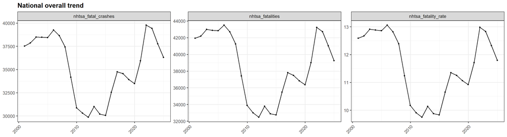

```r
state_codes <- dat %>%
  filter(nchar(geography) == 2, geography != "00") %>%
  distinct(geography) %>% pull(geography)

if (length(state_codes) == 0) {
  cat("_No state-level rows; skipping state trends._\n")
} else {
  pick <- sort(sample(state_codes, min(params$n_states, length(state_codes))))
  # Friendly state names from the FIPS crosswalk, if available.
  fips_path <- proj_path("resources/all_fips.csv.gz")
  lab <- pick
  if (file.exists(fips_path)) {
    fips <- vroom(fips_path, show_col_types = FALSE,
                  col_types = cols(geography = "c"))
    nm <- fips$geography_name[match(pick, fips$geography)]
    lab <- ifelse(is.na(nm), pick, paste0(nm, " (", pick, ")"))
  }
  cat(sprintf("## %d random states — overall\n\n", length(pick)))
  cat(sprintf("States: %s\n\n", paste(lab, collapse = ", ")))

  st <- dat %>% filter(geography %in% pick)
  st <- hold_overall(st, demo_cols)  # overall demographics only
  st$geography <- factor(st$geography, levels = pick, labels = lab)
  trend_plot(st, "geography", "State trends (overall)", held_subtitle(st))
}
```

## 5 random states — overall

States: Alabama (01), Arkansas (05), Michigan (26), North Carolina (37), Pennsylvania (42)

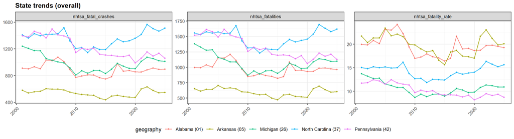

# 5. Choropleth maps

For up to 5 measures, each map shows **4 random years in a 2×2 grid** (overall demographics). Cells that were **suppressed are white with a diagonal hatch** and cells **not asked / not collected that year are solid black** (shown in the legend); other cells use the viridis value scale and cells with no data are grey. State maps use 2-digit FIPS; county maps use 5-digit FIPS. AK, HI and territories are dropped for display.

```r
map_ok <- requireNamespace("sf", quietly = TRUE) &&
          requireNamespace("tigris", quietly = TRUE)

if (!map_ok) {
  cat("_`sf`/`tigris` not available; skipping maps._\n")
} else {
  suppressPackageStartupMessages({ library(sf); library(tigris) })
  options(tigris_use_cache = TRUE)
  DROP_ST <- c("02", "15", "60", "66", "69", "72", "78")  # AK, HI, territories

  # choose measures to map
  map_measures <- roles$values
  if (length(map_measures) > params$n_map_measures)
    map_measures <- sort(sample(map_measures, params$n_map_measures))

  # choose up to 4 random years (shared across measures for comparability)
  all_times <- sort(unique(dat$time))
  map_times <- sort(sample(all_times, min(4, length(all_times))))

  base <- dat %>% filter(time %in% map_times) %>% hold_overall(demo_cols)

  has_ggnewscale <- requireNamespace("ggnewscale", quietly = TRUE)
  has_ggpattern  <- requireNamespace("ggpattern",  quietly = TRUE)
  FLAG_FILL    <- c("Suppressed" = "white", "Not asked / collected" = "black")
  # Suppressed cells also get a diagonal hatch so white doesn't read as a high
  # viridis value; not-asked cells stay solid black.
  FLAG_PATTERN <- c("Suppressed" = "stripe", "Not asked / collected" = "none")
  # Flagged cells get a grey border so white (suppressed) cells stay visible
  # against the white page background.
  FLAG_BORDER <- "grey50"

  # For one measure, build a geometry x year grid and draw a 2x2 (year) facet.
  # Suppressed cells are filled red and not-asked/not-collected cells yellow
  # (on top of the viridis value scale, via a second fill scale).
  draw_maps <- function(geoms, df, level_label) {
    for (m in map_measures) {
      fcs      <- measure_flag_cols(m)
      supp_col <- fcs[grepl("suppress", fcs)]
      miss_col <- fcs[grepl("not_asked|not_collected|not_reported", fcs)]

      sub <- df %>%
        transmute(
          geography, time,
          value = .data[[m]],
          supp  = if (length(supp_col)) as.numeric(.data[[supp_col[1]]]) == 1 else FALSE,
          miss  = if (length(miss_col)) as.numeric(.data[[miss_col[1]]]) == 1 else FALSE
        )
      if (all(is.na(sub$value)) && !any(sub$supp, na.rm = TRUE) &&
          !any(sub$miss, na.rm = TRUE)) next

      md <- expand.grid(geography = geoms$geography, time = map_times,
                        stringsAsFactors = FALSE) %>%
        left_join(sub, by = c("geography", "time")) %>%
        mutate(flag_label = case_when(
          coalesce(supp, FALSE) ~ "Suppressed",
          coalesce(miss, FALSE) ~ "Not asked / collected",
          TRUE                  ~ NA_character_
        )) %>%
        left_join(geoms, by = "geography") %>%
        sf::st_as_sf() %>%
        mutate(year = factor(substr(time, 1, 4),
                             levels = substr(map_times, 1, 4)))

      md_norm <- md %>% filter(is.na(flag_label))
      md_flag <- md %>% filter(!is.na(flag_label)) %>%
        mutate(flag_label = factor(flag_label, levels = names(FLAG_FILL)))

      # Base layer: viridis value scale (flagged cells excluded -> drawn below).
      p <- ggplot() +
        geom_sf(data = md_norm, aes(fill = value),
                color = "white", linewidth = 0.08) +
        scale_fill_viridis_c(option = "viridis", trans = "sqrt",
                             na.value = "grey85", labels = label_number(),
                             name = "value")

      # Overlay layer: suppressed (red) / not-asked (yellow), with its own scale.
      if (nrow(md_flag) > 0 && has_ggnewscale && has_ggpattern) {
        # White suppressed cells get a diagonal hatch; not-asked stay solid
        # black. fill + pattern both keyed to flag_label -> one merged legend.
        p <- p + ggnewscale::new_scale_fill() +
          ggpattern::geom_sf_pattern(
            data = md_flag, aes(fill = flag_label, pattern = flag_label),
            pattern_fill = "grey20", pattern_colour = NA,
            pattern_density = 0.3, pattern_spacing = 0.018, pattern_angle = 45,
            colour = FLAG_BORDER, linewidth = 0.08) +
          scale_fill_manual(values = FLAG_FILL, name = NULL, drop = TRUE) +
          ggpattern::scale_pattern_manual(values = FLAG_PATTERN, name = NULL, drop = TRUE)
      } else if (nrow(md_flag) > 0 && has_ggnewscale) {
        # No ggpattern: solid white/black fills, still with a legend.
        p <- p + ggnewscale::new_scale_fill() +
          geom_sf(data = md_flag, aes(fill = flag_label),
                  color = FLAG_BORDER, linewidth = 0.08) +
          scale_fill_manual(values = FLAG_FILL, name = NULL, drop = TRUE)
      } else if (nrow(md_flag) > 0) {
        # Neither helper: constant fills + a caption instead of a legend.
        p <- p +
          geom_sf(data = md_flag %>% filter(flag_label == "Suppressed"),
                  fill = FLAG_FILL[["Suppressed"]], color = FLAG_BORDER, linewidth = 0.08) +
          geom_sf(data = md_flag %>% filter(flag_label == "Not asked / collected"),
                  fill = FLAG_FILL[["Not asked / collected"]], color = FLAG_BORDER, linewidth = 0.08)
      }

      cap <- if (nrow(md_flag) > 0 && !has_ggnewscale)
        "White (hatched) = suppressed; black = not asked / collected (install 'ggnewscale'/'ggpattern' for a legend)." else NULL

      p <- p +
        facet_wrap(~year, ncol = 2) +
        coord_sf(crs = 5070, datum = NA) +
        labs(title = sprintf("%s — %s", m, level_label), caption = cap) +
        theme_void(base_size = 11) +
        theme(plot.title = element_text(face = "bold", hjust = 0.5, size = 12),
              plot.caption = element_text(hjust = 0.5, color = "grey40", size = 8),
              strip.text = element_text(face = "bold", size = 11),
              legend.position = "right")
      print(p)
    }
  }

  # ---- state maps ----
  state_df <- base %>% filter(nchar(geography) == 2, geography != "00")
  if (nrow(state_df) > 0) {
    cat(sprintf("## State maps (%d measures; years %s)\n\n",
                length(map_measures), paste(substr(map_times, 1, 4), collapse = ", ")))
    states_sf <- tryCatch(
      tigris::states(cb = TRUE, resolution = "5m", year = 2022,
                     progress_bar = FALSE) %>%
        filter(!STATEFP %in% DROP_ST) %>%
        transmute(geography = as.character(GEOID)),
      error = function(e) { cat("_Could not fetch state geometry: ", conditionMessage(e), "_\n"); NULL })
    if (!is.null(states_sf)) draw_maps(states_sf, state_df, "state")
  }

  # ---- county maps ----
  county_df <- base %>% filter(nchar(geography) == 5)
  if (nrow(county_df) > 0) {
    cat(sprintf("\n\n## County maps (%d measures; years %s)\n\n",
                length(map_measures), paste(substr(map_times, 1, 4), collapse = ", ")))
    counties_sf <- tryCatch(
      tigris::counties(cb = TRUE, resolution = "5m", year = 2022,
                       progress_bar = FALSE) %>%
        filter(!STATEFP %in% DROP_ST) %>%
        transmute(geography = as.character(GEOID)),
      error = function(e) { cat("_Could not fetch county geometry: ", conditionMessage(e), "_\n"); NULL })
    if (!is.null(counties_sf)) draw_maps(counties_sf, county_df, "county")
  }

  if (nrow(state_df) == 0 && nrow(county_df) == 0)
    cat("_No state- or county-level rows; skipping maps._\n")
}
```

## State maps (3 measures; years 2010, 2013, 2017, 2018)

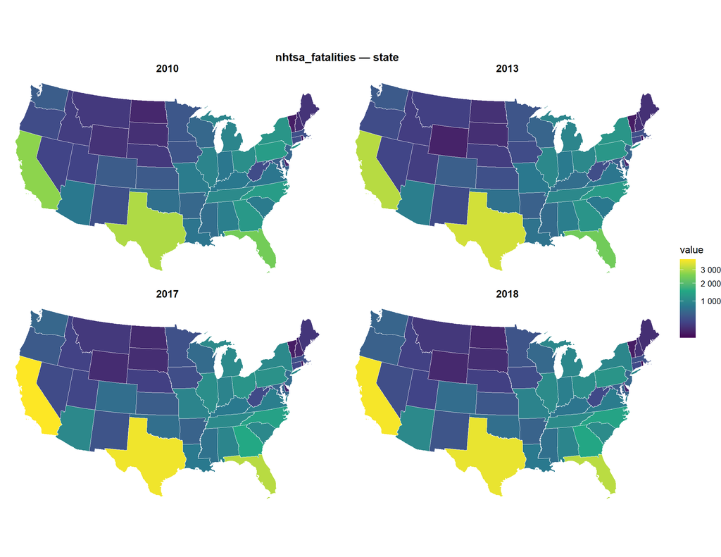

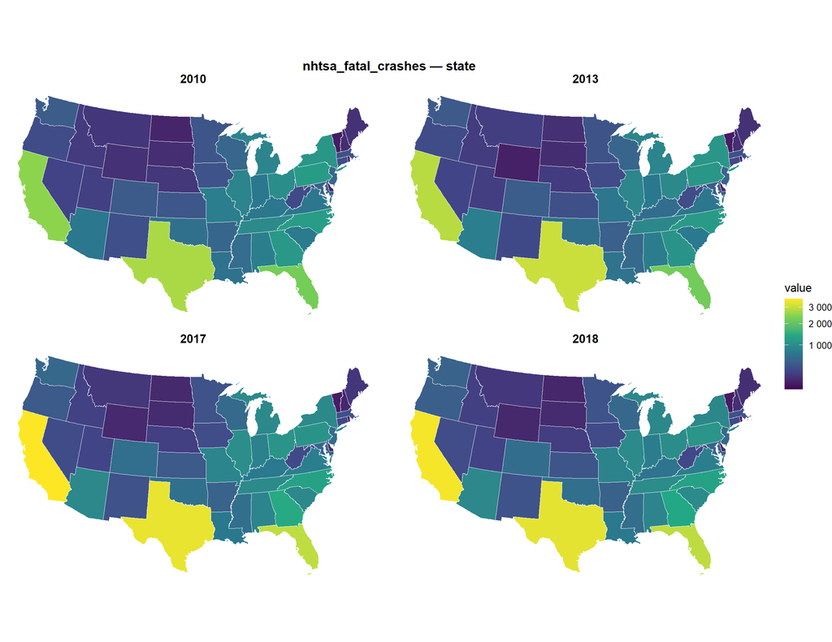

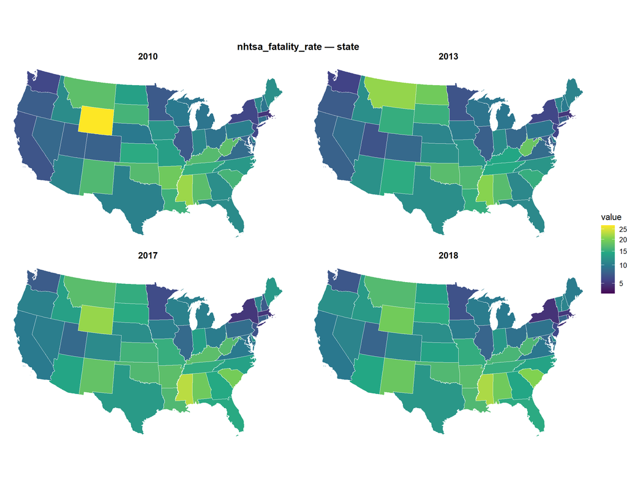

## County maps (3 measures; years 2010, 2013, 2017, 2018)

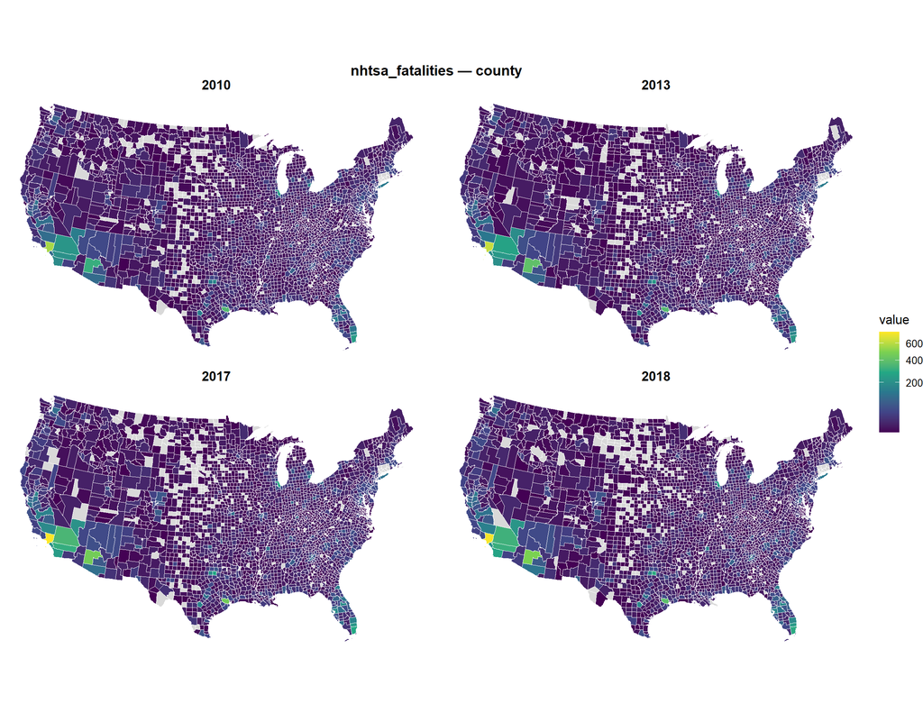

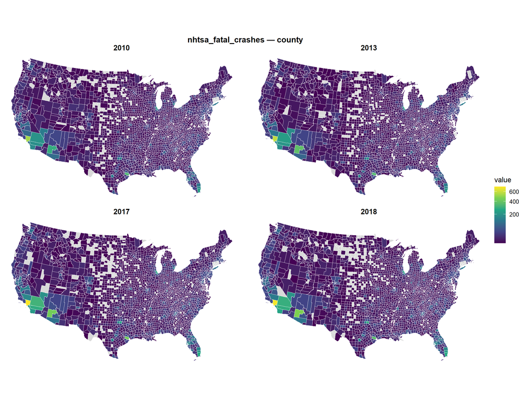

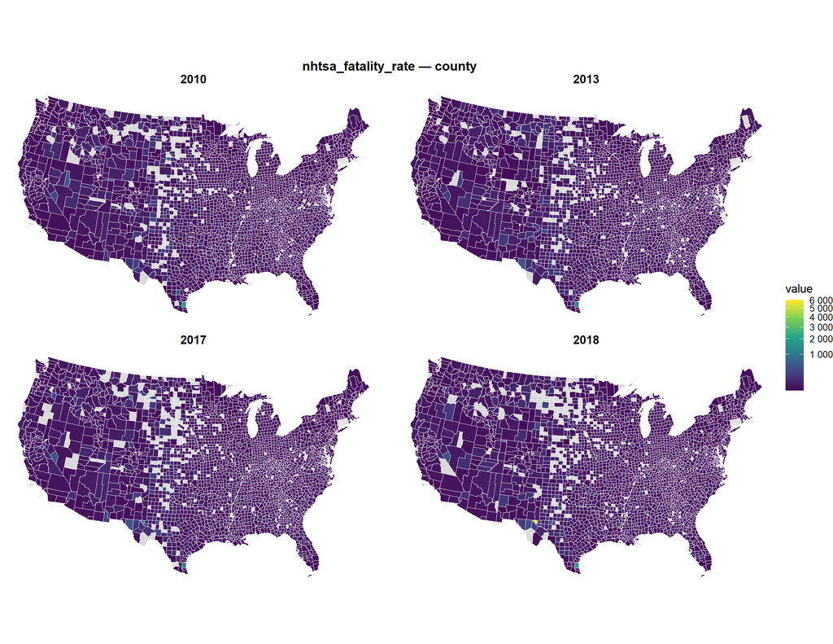

```r
cat("_Maps disabled (`make_maps: false`)._\n")
```

# 6. Comparison with a similar source

If `compare_file` is supplied, national overall trends for measures present in both datasets are overlaid. Measures are matched by column name, or by the explicit `main_measures` / `compare_measures` mapping if provided.

```r
cmp_path <- proj_path(params$compare_file)
if (!nzchar(cmp_path) || !file.exists(cmp_path)) {
  cat("_No comparison source supplied (`compare_file` is blank), skipping._\n")
} else {
  # Build the measure mapping (main measure -> comparison measure).
  mm <- trimws(strsplit(params$main_measures, ",")[[1]])
  cm <- trimws(strsplit(params$compare_measures, ",")[[1]])
  mm <- mm[nzchar(mm)]; cm <- cm[nzchar(cm)]
  if (length(mm) && length(mm) == length(cm)) {
    pairs <- data.frame(main = mm, comp = cm, stringsAsFactors = FALSE)
  } else {
    # Read header only to find shared measure names — avoid loading all data.
    cdat_hdr <- vroom(cmp_path, show_col_types = FALSE, n_max = 0,
                      col_types = cols(geography = "c", time = "c"))
    shared <- intersect(roles$values, classify_columns(cdat_hdr)$values)
    pairs <- data.frame(main = shared, comp = shared, stringsAsFactors = FALSE)
  }

  if (nrow(pairs) == 0) {
    cat("_No measures matched between the two sources. Provide `main_measures` / `compare_measures` to map them manually._\n")
  } else {
    # Load only the columns needed: id cols + demo cols + the comparison measures.
    cdat_hdr <- vroom(cmp_path, show_col_types = FALSE, n_max = 0,
                      col_types = cols(geography = "c", time = "c"))
    cmp_demo_cols <- setdiff(
      names(cdat_hdr)[vapply(cdat_hdr, function(x) is.character(x) || is.factor(x), logical(1))],
      c("geography", "time")
    )
    cdat <- vroom(cmp_path, show_col_types = FALSE,
                  col_types = cols(geography = "c", time = "c"),
                  col_select = any_of(c("geography", "time", cmp_demo_cols, pairs$comp)))
    croles <- classify_columns(cdat)

    cat(sprintf("Overlaying **%d** measure(s) at the national level vs. **%s**.\n\n",
                nrow(pairs), params$compare_label))
    main_nat  <- hold_overall(dat  %>% filter(geography == "00"), roles$demo)
    comp_nat  <- hold_overall(cdat %>% filter(geography == "00"), croles$demo)

    main_name <- basename(dirname(dirname(params$data_file)))
    cmp_name  <- basename(dirname(dirname(params$compare_file)))
    combined <- bind_rows(
      lapply(seq_len(nrow(pairs)), function(i) {
        bind_rows(
          main_nat %>% transmute(time = as.Date(time), measure = pairs$main[i],
                                 value = .data[[pairs$main[i]]],
                                 source = paste0(main_name, ": ", pairs$main[i])),
          comp_nat %>% transmute(time = as.Date(time), measure = pairs$main[i],
                                 value = .data[[pairs$comp[i]]],
                                 source = paste0(cmp_name, ": ", pairs$comp[i]))
        )
      })
    ) %>% filter(!is.na(value))

    p <- ggplot(combined, aes(time, value, color = source, group = source)) +
      geom_line(linewidth = 0.6) + geom_point(size = 0.8) +
      facet_wrap(~measure, scales = "free_y", ncol = FACET_NCOL) +
      labs(title = "National overall: this dataset vs. comparison source",
           x = NULL, y = NULL, color = NULL) +
      theme_bw(base_size = 11) +
      theme(legend.position = "bottom",
            plot.title = element_text(face = "bold"),
            strip.text = element_text(size = 9),
            axis.text.x = element_text(angle = 45, hjust = 1))
    print(p)
  }
}
```

Overlaying **1** measure(s) at the national level vs. **Comparison source**.

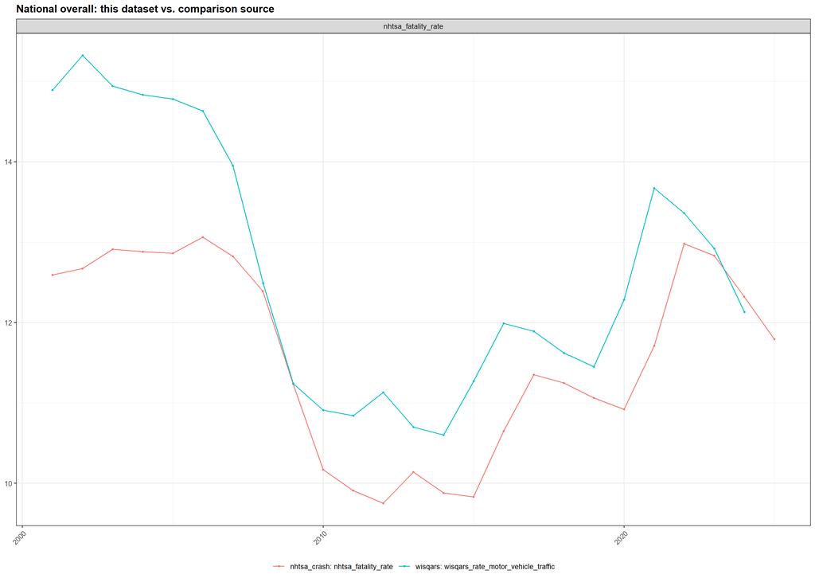

````r
cat("<details><summary>Session info</summary>\n\n```\n")
````

**Session info**

[output not shown]

R version 4.4.3 (2025-02-28 ucrt) Platform: x86_64-w64-mingw32/x64 Running under: Windows 11 x64 (build 26200)

Matrix products: default

locale: [1] LC_COLLATE=English_United States.utf8 [2] LC_CTYPE=English_United States.utf8  
[3] LC_MONETARY=English_United States.utf8 [4] LC_NUMERIC=C  
[5] LC_TIME=English_United States.utf8

time zone: America/New_York tzcode source: internal

attached base packages: [1] stats graphics grDevices utils datasets methods base

other attached packages: [1] tigris_2.2.1 sf_1.1-1 knitr_1.49 scales_1.4.0 ggplot2_4.0.3 [6] vroom_1.6.5 tidyr_1.3.1 dplyr_1.1.4

````r
cat("\n```\n</details>\n")
````

[output not shown]